# Lab 4 Diversity

### Set up the environment

```r
library(dada2)
```

```r
library(ggplot2)
library(vegan)
library(reshape2)
options(stringsAsFactors = F)
```

#### Functions

```r
###
#        Function phylotype_analysis             #
###

phylotype_analysis <- function(obj, tax) {
  #obj: microbiome object with at least 1 slot (data)
  #tax: a tax object (named list taxa as names values in the list are seq ids)
  obj.out <- NULL
  for (h in 1:length(tax)) {
    df <- NULL
    #print(h)#debugging
    for (i in 1:length(tax[[h]])) {
      #print(i)#debugging
      v1       <- obj$data[, unlist(tax[[h]][[i]])]
      v2       <- names(tax[[h]])[i]
      if (is.null(dim(v1))) {
        df[[v2]] <- v1
      } else{
        df[[v2]] <- rowSums(v1)
      }
    }
    obj.out[[names(tax)[h]]] <- as.data.frame(df)
  }
  return(obj.out)
}

make_taxa_df <- function(tax){

  kingdom.df <- replicate(length(unique(tax[, 2])), c())
  names(kingdom.df) <- unique(tax[, 2])
  phylum.df  <- replicate(length(unique(tax[, 3])), c())
  names(phylum.df) <- unique(tax[, 3])
  class.df   <- replicate(length(unique(tax[, 4])), c())
  names(class.df) <- unique(tax[, 4])
  order.df   <- replicate(length(unique(tax[, 5])), c())
  names(order.df) <- unique(tax[, 5])
  family.df  <- replicate(length(unique(tax[, 6])), c())
  names(family.df) <- unique(tax[, 6])
  genus.df   <- replicate(length(unique(tax[, 7])), c())
  names(genus.df) <- unique(tax[, 7])

  for (i in 1:nrow(tax)) {
    kingdom.df[[tax[i, 2]]] <-
      c(kingdom.df[[tax[i, 2]]], tax[i, 1])
    phylum.df[[tax[i, 3]]]  <-
      c(phylum.df[[tax[i, 3]]], tax[i, 1])
    class.df[[tax[i, 4]]]   <-
      c(class.df[[tax[i, 4]]], tax[i, 1])
    order.df[[tax[i, 5]]]   <-
      c(order.df[[tax[i, 5]]], tax[i, 1])
    family.df[[tax[i, 6]]]  <-
      c(family.df[[tax[i, 6]]], tax[i, 1])
    genus.df[[tax[i, 7]]]   <-
      c(genus.df[[tax[i, 7]]], tax[i, 1])
  }

  tax.obj <- NULL
  tax.obj$kingdom <- kingdom.df
  tax.obj$phylum  <- phylum.df
  tax.obj$class   <- class.df
  tax.obj$order   <- order.df
  tax.obj$family  <- family.df
  tax.obj$genus   <- genus.df

  return(tax.obj)
}
```

### Import data

First we need to import the data that we generated before.

```r
#importing chimera filtered ASV table
seqtab.nochim <- read.table("../out_files/seqtab_nochim.txt",
                            sep = "\t",
                            row.names = 1,
                            header = T)

#importing taxonomy table
taxa <- read.table("../out_files/taxa.txt",
                   sep = "\t",
                   row.names = 1,
                   header = T
                   )

#make a mapping of ASV number to ASV sequence
asv.dict <- data.frame(asv = paste("asv", seq(1,1817), sep = ""),
                       seq = colnames(seqtab.nochim))

#clean up asv nams
rownames(taxa) <- asv.dict$asv
colnames(seqtab.nochim) <- asv.dict$asv

write.table(asv.dict,
            file = "../out_files/asv_dict.txt",
            quote = FALSE,
            sep = "\t",
            )

#import metadata

metadata <- read.table("../metadata/metadata_biogeography_modified.txt",
                   sep = "\t",
                   header = T
                   )

all(rownames(metadata) %in% rownames(seqtab.nochim))
```

```
## [1] TRUE
```

```r
all(rownames(metadata) == rownames(seqtab.nochim))
```

```
## [1] TRUE
```

### Normalize

Next we will generate data normalized three ways. First rarefied, then relative abundance, then center log ratio transformed.

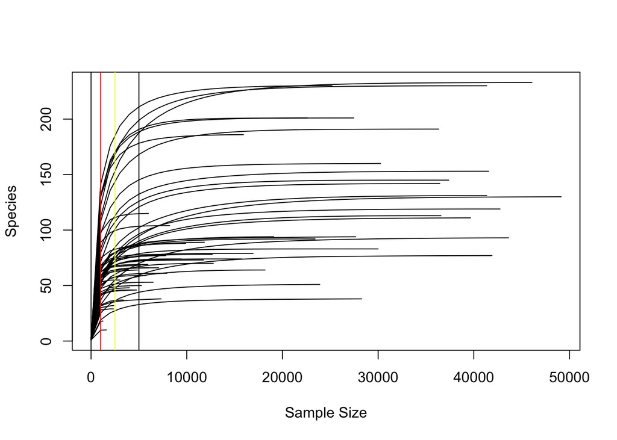

```r
raresamp <- min(rowSums(seqtab.nochim))

#now we can plot the curves
rarecurve(seqtab.nochim, step = 1000,
          sample = 0,
          label = F,
          col = "black")

abline(v = 1000, col = "red")
abline(v = 2500, col = "yellow")
abline(v = 5000, col = "black")
```

```r
set.seed(731)
seqtab.nochim.rare <- rrarefy(seqtab.nochim, 2500) #rarefy
seqtab.nochim.rclr <- decostand(seqtab.nochim, method = "rclr") #center log blah blah blah
seqtab.nochim.rel <- decostand(seqtab.nochim, method = "total") #relative abundance
```

In practice we would choose one (perhaps two) methods of normalization. For illustration purpose only we can compare the number of asvs in each data set.

```r
cor.test(specnumber(seqtab.nochim.rare), specnumber(seqtab.nochim.rel) )
```

```
##
##  Pearson's product-moment correlation
##
## data:  specnumber(seqtab.nochim.rare) and specnumber(seqtab.nochim.rel)
## t = 27.932, df = 55, p-value < 2.2e-16
## alternative hypothesis: true correlation is not equal to 0
## 95 percent confidence interval:
##  0.9435772 0.9802198
## sample estimates:
##       cor
## 0.9665126
```

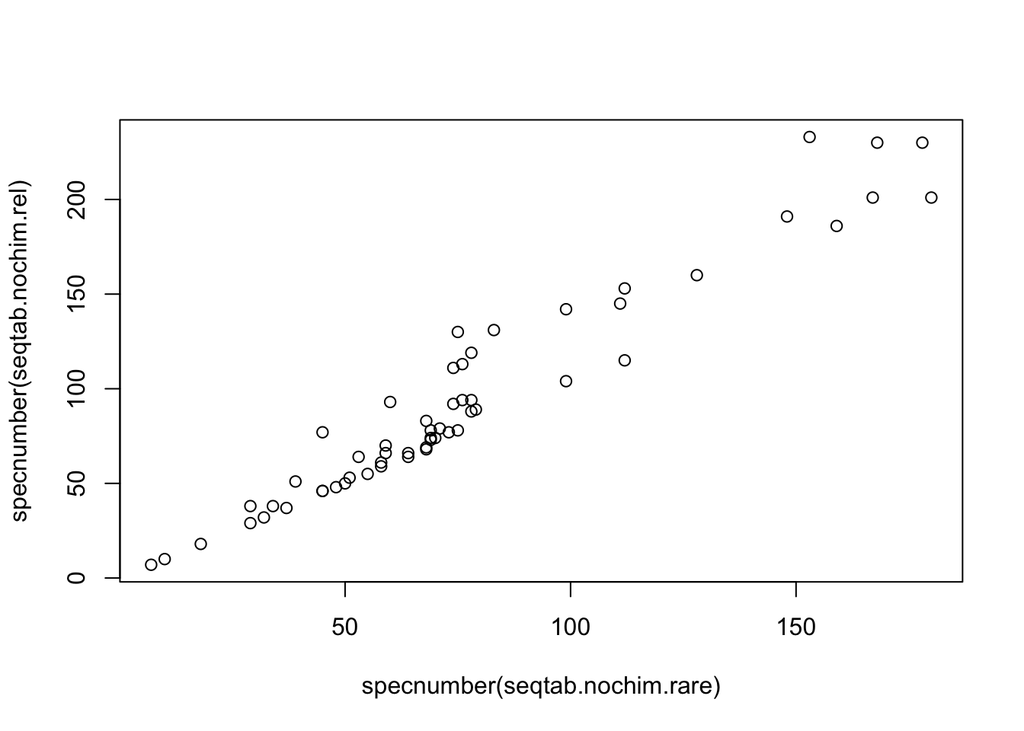

```r
plot(specnumber(seqtab.nochim.rare), specnumber(seqtab.nochim.rel) )
```

```r
cor.test(specnumber(seqtab.nochim.rare), specnumber(seqtab.nochim.rclr) )
```

```
##
##  Pearson's product-moment correlation
##
## data:  specnumber(seqtab.nochim.rare) and specnumber(seqtab.nochim.rclr)
## t = 28.626, df = 55, p-value < 2.2e-16
## alternative hypothesis: true correlation is not equal to 0
## 95 percent confidence interval:
##  0.9461228 0.9811283
## sample estimates:
##       cor
## 0.9680404
```

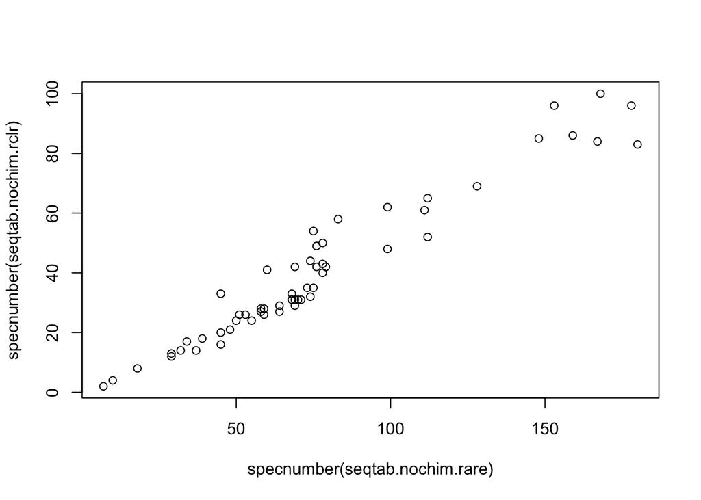

```r
plot(specnumber(seqtab.nochim.rare), specnumber(seqtab.nochim.rclr) )
```

```r
cor.test(specnumber(seqtab.nochim.rel), specnumber(seqtab.nochim.rclr) )
```

```
##
##  Pearson's product-moment correlation
##
## data:  specnumber(seqtab.nochim.rel) and specnumber(seqtab.nochim.rclr)
## t = 62.272, df = 55, p-value < 2.2e-16
## alternative hypothesis: true correlation is not equal to 0
## 95 percent confidence interval:
##  0.9880670 0.9958779
## sample estimates:
##       cor
## 0.9929829
```

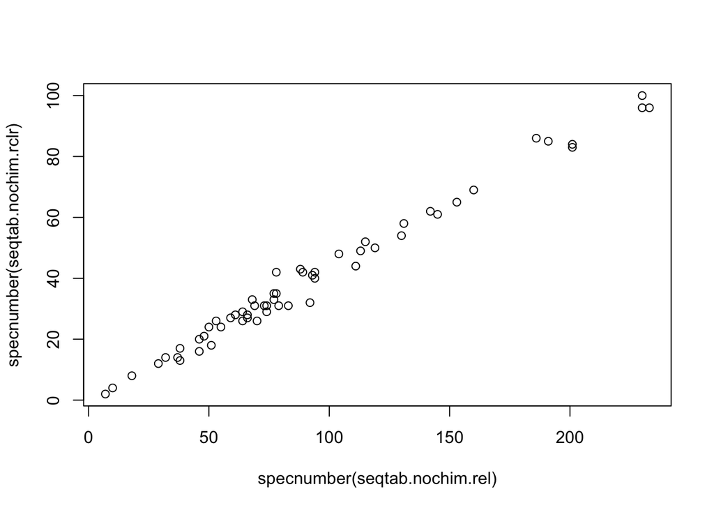

```r
plot(specnumber(seqtab.nochim.rel), specnumber(seqtab.nochim.rclr) )
```

Now, reviewer 3 suggested that we lost 80% of our data given our subsampling thresholds. But that always seemed a little off to me, so just to twist the knife, lets look at the actual data lost during rarefaction. First, we will calculate total number of ASVs we lose the number of the samples filtered ASVs occur in.

```r
#total number of asvs
length(colSums(seqtab.nochim.rare)[which(colSums(seqtab.nochim.rare)==0)])
```

```
## [1] 338
```

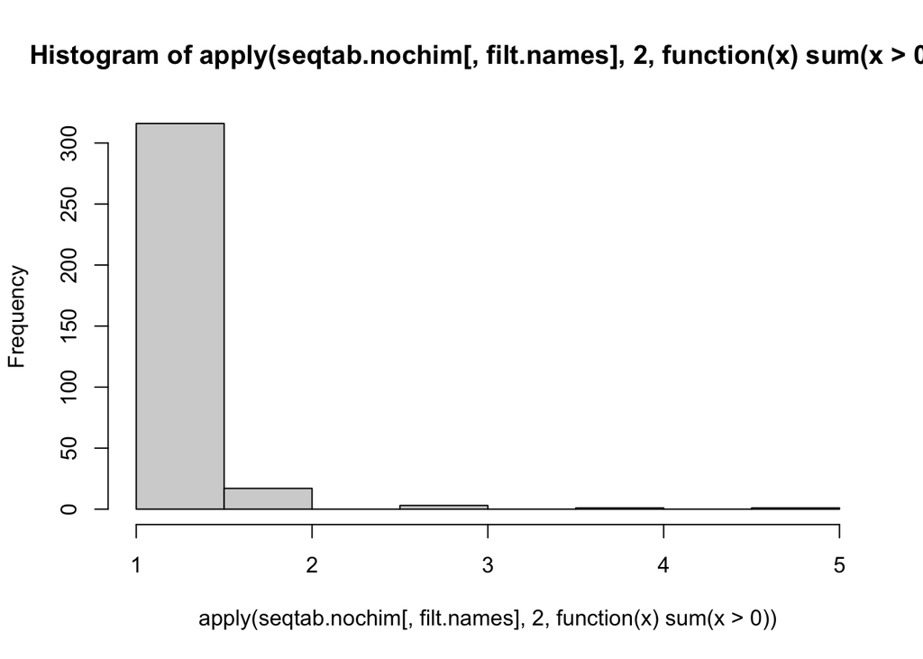

```r
filt.names <- names(colSums(seqtab.nochim.rare)[which(colSums(seqtab.nochim.rare)==0)])

#number of samples

hist(apply(seqtab.nochim[,filt.names], 2, function(x) sum(x > 0)))
```

```r
#How many occur in more than one sample
sum(apply(seqtab.nochim[,filt.names], 2, function(x) sum(x > 0)) > 1 )
```

```
## [1] 22
```

Above we found that the vast majority of ASVs that are filtered would be found in only one sample. Now we want to see the total abundance accross all samples (raw counts)

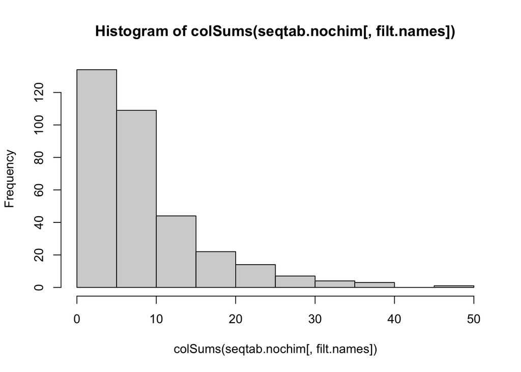

```r
#What is the total abundance across all samples
hist(colSums(seqtab.nochim[,filt.names]))
```

```r
#total abundance lost
sum(seqtab.nochim[,filt.names])
```

```
## [1] 3074
```

```r
#% total loss
sum(seqtab.nochim[,filt.names])/sum(seqtab.nochim)
```

```
## [1] 0.002940718
```

So here we lost less than 1% of all abundance in the data frame. It is true that we filtered ~87% of data here, but since it is randomly subsampled without replacement, the new profiles will reflect the abundance in the data sets filtered with other methods. All that said its sometimes just a little easier to go along with the zealots.

### Alpha Diversity

#### Calculate diversity

Alpha diversity is one place where rarefaction is still pretty well accepted so for this analysis we will use our rarefied data.

```r
#richness
richness.rare <- data.frame(specnumber(seqtab.nochim.rare))
colnames(richness.rare) <- "richness"
head(richness.rare)
```

|  | richness |
| --- | --- |
| F10GD_032522_AACTTTCAGGAG_L001 | 112 |
| F10GM_032522_ACACACCCTGAC_L001 | 112 |
| F10GP_032522_CGAATACTGACA_L001 | 32 |
| F10GS_032522_AACCGCATAAGT_L001 | 76 |
| F10SB_032522_AGATTCGCTCGA_L001 | 68 |
| F1GD_032122_AAGGCGCTCCTT_L001 | 128 |

```r
#shannon entropy
shannon.rare <- data.frame(diversity(seqtab.nochim.rare, index = "shannon"))
colnames(shannon.rare) <- "shannon"
head(shannon.rare)
```

|  | shannon |
| --- | --- |
| F10GD_032522_AACTTTCAGGAG_L001 | 2.477356 |
| F10GM_032522_ACACACCCTGAC_L001 | 3.483941 |
| F10GP_032522_CGAATACTGACA_L001 | 2.215719 |
| F10GS_032522_AACCGCATAAGT_L001 | 2.549873 |
| F10SB_032522_AGATTCGCTCGA_L001 | 2.227000 |
| F1GD_032122_AAGGCGCTCCTT_L001 | 2.864138 |

#### Plot richness

This is pretty meaningless without context so lets add some information to our data frame so we can visualize better. But first we will check to make sure the data frames are in the same order

```r
all(rownames(shannon.rare) == rownames(metadata))
```

```
## [1] TRUE
```

```r
all(rownames(richness.rare) == rownames(metadata))
```

```
## [1] TRUE
```

Good. Now we can add some metadata and plot starting with richness

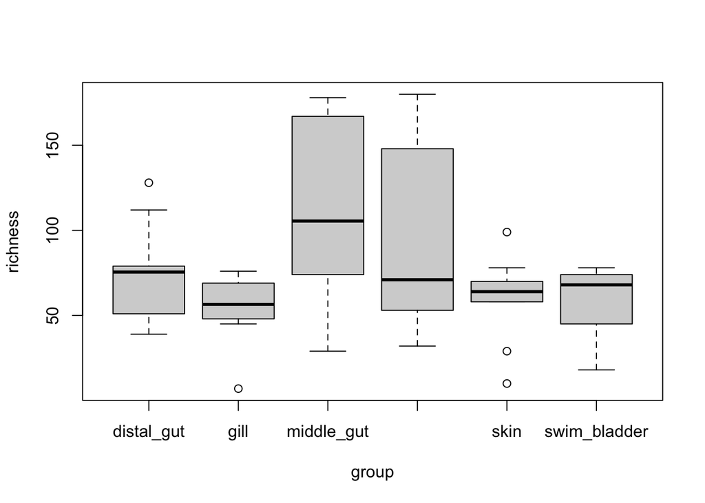

```r
richness.rare$group <- metadata$tissue

boxplot(data = richness.rare, richness ~ group) #fine but ugly
```

I don’t like how these plots are ordered. Since ggplot likes to order by level we can relevel the factors to change this.

```r
levels(metadata$tissue) # looks like this is a character vector
```

```r
metadata$tissue <- factor(metadata$tissue,
       levels = c("skin", "gill", "swim_bladder", "proximal_gut", "middle_gut", "distal_gut")
       )
```

Now we can make a nicer plot with ggplot and the revised levels.

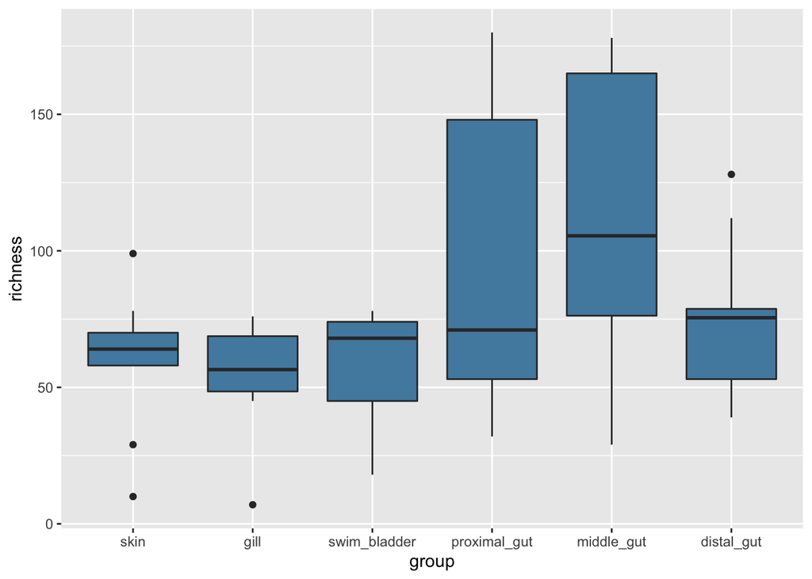

```r
richness.rare$group <- metadata$tissue #need to rerun this because we modified

rich.plot <- ggplot(data = richness.rare, aes(x = group,
                                                    y = richness)) +
  geom_boxplot(fill = "#528AAE") #fill by hex code #528AAE

rich.plot
```

#### Plot shannon

Now we can do the same thing with Shannon entropy. Note we don’t have to relevel again because we only need to do this once if we modify the original metadata object.

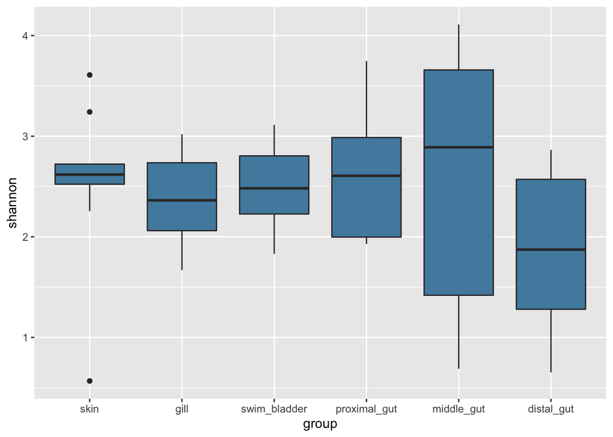

```r
shannon.rare$group <- metadata$tissue
shannon.plot <- ggplot(data = shannon.rare, aes(x = group,
                                                    y = shannon)) +
  geom_boxplot(fill = "#528AAE") #fill by hex code #528AAE

shannon.plot
```

#### Some statistics

It looks like the richness, and maybe entropy vary across groups. We can use simple stats to find out if this significant.

```r
kruskal.test(richness.rare$richness ~ richness.rare$group) # marginally sig
```

```
##
##  Kruskal-Wallis rank sum test
##
## data:  richness.rare$richness by richness.rare$group
## Kruskal-Wallis chi-squared = 10.817, df = 5, p-value = 0.05513
```

```r
pairwise.wilcox.test(x = richness.rare$richness,
                     g = richness.rare$group,p.adjust.method = "holm"
                      )
```

[output not shown]

```
##
##  Pairwise comparisons using Wilcoxon rank sum test with continuity correction
##
## data:  richness.rare$richness and richness.rare$group
##
##              skin  gill  swim_bladder proximal_gut middle_gut
## gill         1.000 -     -            -            -
## swim_bladder 1.000 1.000 -            -            -
## proximal_gut 1.000 1.000 1.000        -            -
## middle_gut   0.319 0.078 0.310        1.000        -
## distal_gut   1.000 1.000 1.000        1.000        1.000
##
## P value adjustment method: holm
```

```r
kruskal.test(shannon.rare$shannon ~ shannon.rare$group) # no sig
```

```
##
##  Kruskal-Wallis rank sum test
##
## data:  shannon.rare$shannon by shannon.rare$group
## Kruskal-Wallis chi-squared = 5.2267, df = 5, p-value = 0.3888
```

```r
pairwise.wilcox.test(x = shannon.rare$shannon,
                     g = shannon.rare$group,p.adjust.method = "holm"
                      ) #nobody uses bonferonni unless they are a sadist
```

```
##
##  Pairwise comparisons using Wilcoxon rank sum exact test
##
## data:  shannon.rare$shannon and shannon.rare$group
##
##              skin gill swim_bladder proximal_gut middle_gut
## gill         1    -    -            -            -
## swim_bladder 1    1    -            -            -
## proximal_gut 1    1    1            -            -
## middle_gut   1    1    1            1            -
## distal_gut   1    1    1            1            1
##
## P value adjustment method: holm
```

For those unfamiliar with the holm method of family wise error rate control that doesn’t suck. Specifically it applies a less conservative measure of control than bonferonni which effectively multiplies your p-value by the number of test. We will talk more about stats later so for now we can move on…

### Beta Diversity

Next we will look to see of diversity of our different tissues varies. Here we will use PCA to start. Keep in mind these are exploratory techniques so we can use as man of them as we like.

```r
seq.rare.prcomp <- prcomp(seqtab.nochim.rel, scale =F, center = F) # defaults
summary(seq.rare.prcomp)
```

```
## Importance of components:
##                           PC1    PC2     PC3     PC4     PC5     PC6     PC7
## Standard deviation     0.4108 0.2274 0.15051 0.03866 0.03354 0.02747 0.02675
## Proportion of Variance 0.6728 0.2062 0.09031 0.00596 0.00448 0.00301 0.00285
## Cumulative Proportion  0.6728 0.8790 0.96935 0.97531 0.97979 0.98280 0.98565
##                            PC8     PC9    PC10    PC11    PC12    PC13    PC14
## Standard deviation     0.02451 0.02335 0.01767 0.01581 0.01439 0.01260 0.01241
## Proportion of Variance 0.00239 0.00217 0.00124 0.00100 0.00083 0.00063 0.00061
## Cumulative Proportion  0.98805 0.99022 0.99147 0.99246 0.99329 0.99392 0.99454
##                           PC15    PC16    PC17    PC18     PC19     PC20
## Standard deviation     0.01196 0.01074 0.01046 0.01005 0.009556 0.008868
## Proportion of Variance 0.00057 0.00046 0.00044 0.00040 0.000360 0.000310
## Cumulative Proportion  0.99511 0.99557 0.99600 0.99640 0.996770 0.997080
##                            PC21    PC22     PC23     PC24     PC25     PC26
## Standard deviation     0.008704 0.00847 0.008209 0.007753 0.007362 0.006568
## Proportion of Variance 0.000300 0.00029 0.000270 0.000240 0.000220 0.000170
## Cumulative Proportion  0.997380 0.99767 0.997940 0.998180 0.998390 0.998570
##                            PC27    PC28     PC29     PC30     PC31     PC32
## Standard deviation     0.006273 0.00622 0.005408 0.005106 0.005032 0.004815
## Proportion of Variance 0.000160 0.00015 0.000120 0.000100 0.000100 0.000090
## Cumulative Proportion  0.998720 0.99888 0.998990 0.999100 0.999200 0.999290
##                            PC33     PC34     PC35     PC36     PC37     PC38
## Standard deviation     0.004426 0.004254 0.003943 0.003706 0.003576 0.003366
## Proportion of Variance 0.000080 0.000070 0.000060 0.000050 0.000050 0.000050
## Cumulative Proportion  0.999370 0.999440 0.999500 0.999560 0.999610 0.999650
##                            PC39     PC40     PC41    PC42     PC43     PC44
## Standard deviation     0.003326 0.002999 0.002949 0.00284 0.002703 0.002628
## Proportion of Variance 0.000040 0.000040 0.000030 0.00003 0.000030 0.000030
## Cumulative Proportion  0.999700 0.999730 0.999770 0.99980 0.999830 0.999860
##                           PC45     PC46     PC47     PC48     PC49     PC50
## Standard deviation     0.00247 0.002388 0.002193 0.002142 0.001865 0.001686
## Proportion of Variance 0.00002 0.000020 0.000020 0.000020 0.000010 0.000010
## Cumulative Proportion  0.99988 0.999910 0.999920 0.999940 0.999960 0.999970
##                            PC51    PC52     PC53      PC54      PC55      PC56
## Standard deviation     0.001572 0.00152 0.001111 0.0009166 0.0007459 0.0006143
## Proportion of Variance 0.000010 0.00001 0.000000 0.0000000 0.0000000 0.0000000
## Cumulative Proportion  0.999980 0.99999 0.999990 1.0000000 1.0000000 1.0000000
##                             PC57
## Standard deviation     0.0004842
## Proportion of Variance 0.0000000
## Cumulative Proportion  1.0000000
```

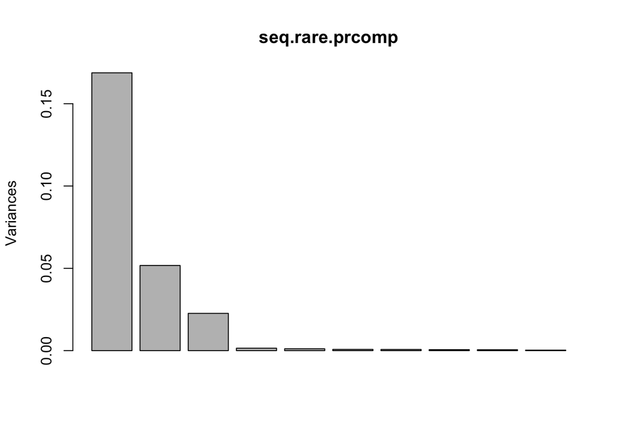

```r
plot(seq.rare.prcomp)
```

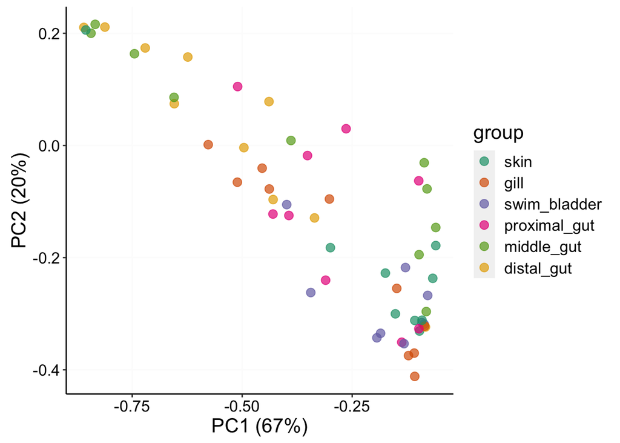

```r
seqtab_rare_pca.df <- as.data.frame(seq.rare.prcomp$x[,1:5])

#add metadata for plotting
seqtab_rare_pca.df$group <- metadata$tissue

seqtab_rare_pca.plot <- ggplot(data = seqtab_rare_pca.df,
                                 aes(x = PC1,
                                     y = PC2,
                                     color = group
                                     )
                               )
seqtab_rare_pca.plot +
  geom_point(size = 3, alpha = .7)+
  scale_color_brewer(palette = "Dark2")+
  theme(
    text = element_text(size = 16, colour = "black"),
    panel.grid.major = element_line(colour = "grey99"),
    panel.grid.minor = element_blank(),
    panel.background = element_blank(),
    axis.line = element_line(colour = "black"),
    axis.text = element_text(colour = "black"),
    aspect.ratio = 1,
  )+
  xlab("PC1 (67%)")+
  ylab("PC2 (20%)")
```

We can try something similar with the log ratio transformed too, but it wont work with PCA like I originally thought.

```r
#PCoA
seq.rclr.cmdscale <- cmdscale(vegdist(x = seqtab.nochim, method = "robust.aitchison"), k =5, eig = T)

#percent variation explained
round(seq.rclr.cmdscale$eig*100/sum(seq.rclr.cmdscale$eig),1)
```

```
##  [1] 14.1  9.2  8.2  5.4  4.0  3.1  2.8  2.7  2.5  2.4  2.3  2.2  2.1  2.0  1.9
## [16]  1.8  1.7  1.6  1.6  1.5  1.4  1.4  1.3  1.2  1.2  1.1  1.1  1.1  1.0  1.0
## [31]  0.9  0.9  0.9  0.9  0.8  0.8  0.8  0.7  0.7  0.6  0.6  0.6  0.6  0.6  0.5
## [46]  0.5  0.5  0.5  0.5  0.4  0.4  0.4  0.4  0.3  0.2  0.1  0.0
```

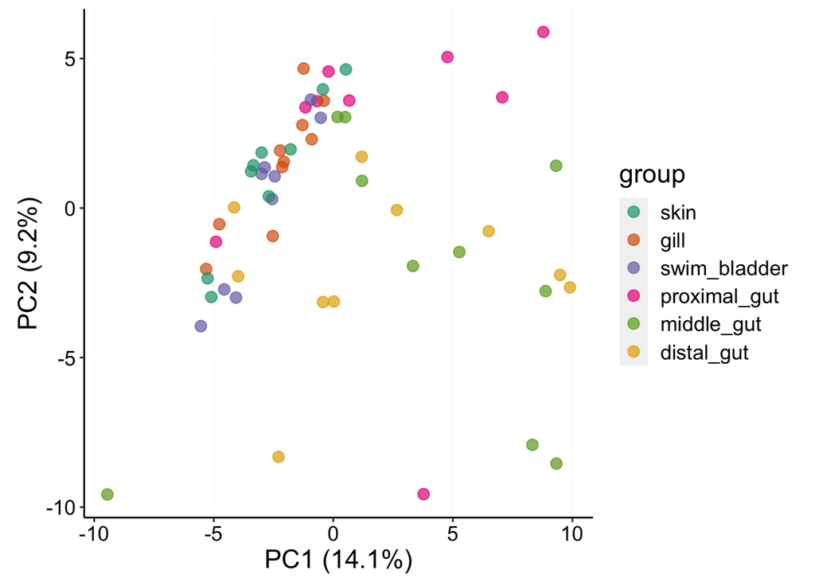

```r
#grab the dims
seq.rclr.cmdscale.df <- as.data.frame(seq.rclr.cmdscale$points)

#add metadata for plotting
seq.rclr.cmdscale.df$group <- metadata$tissue
colnames(seq.rclr.cmdscale.df) <- c("Dim1","Dim2", "Dim3", "Dim4", "Dim5", "group")


seq.rclr.cmdscale.plot <- ggplot(data = seq.rclr.cmdscale.df,
                                 aes(x = Dim1,
                                     y = Dim2,
                                     color = group
                                     )
                               )
seq.rclr.cmdscale.plot +
  geom_point(size = 3, alpha = .7)+
  scale_color_brewer(palette = "Dark2")+
  theme(
    text = element_text(size = 16, colour = "black"),
    panel.grid.major = element_line(colour = "grey99"),
    panel.grid.minor = element_blank(),
    panel.background = element_blank(),
    axis.line = element_line(colour = "black"),
    axis.text = element_text(colour = "black"),
    aspect.ratio = 1,
  )+
  xlab("PC1 (14.1%)")+
  ylab("PC2 (9.2%)")
```

Finally, lets see if the groups label correlates with microbiome diversity.

```r
set.seed(731) # makes this reproducible

seq_rel.adonis2 <- adonis2(seqtab.nochim.rel ~  tissue,
                                permutations = 5000,
                                by = "terms",
                                data = metadata,
                                na.action = na.omit)


seq_rclr.adonis2 <- adonis2(seqtab.nochim ~  tissue ,
                                method ="robust.aitchison",
                                permutations = 5000,
                                by = "terms",
                                data = metadata,
                                na.action = na.omit)


seq_rel.adonis2
```

|  | Df | SumOfSqs | R2 | F | Pr(>F) |
| --- | --- | --- | --- | --- | --- |
| tissue | 5 | 3.217977 | 0.2491717 | 3.384997 | 0.00019996 |
| Residual | 51 | 9.696720 | 0.7508283 | NA | NA |
| Total | 56 | 12.914697 | 1.0000000 | NA | NA |

```r
seq_rclr.adonis2
```

|  | Df | SumOfSqs | R2 | F | Pr(>F) |
| --- | --- | --- | --- | --- | --- |
| tissue | 5 | 1202.774 | 0.1422976 | 1.692237 | 0.00019996 |
| Residual | 51 | 7249.749 | 0.8577024 | NA | NA |
| Total | 56 | 8452.522 | 1.0000000 | NA | NA |

One last thing that should be noted. Adonis2, despite the claims of the authors, is sensitive to data dispersion. To see if dispersion differs between groups we have to dig a little deeper.

```r
disp.rclr <- betadisper(vegdist(seqtab.nochim, method = "robust.aitchison"), group = metadata$tissue)

disp.rel <- betadisper(vegdist(seqtab.nochim, method = "bray"), group = metadata$tissue)


anova(disp.rclr)
```

|  | Df | Sum Sq | Mean Sq | F value | Pr(>F) |
| --- | --- | --- | --- | --- | --- |
| Groups | 5 | 306.8947 | 61.378938 | 7.909599 | 1.417668e-05 |
| Residuals | 51 | 395.7629 | 7.760057 | NA | NA |

```r
anova(disp.rel)
```

|  | Df | Sum Sq | Mean Sq | F value | Pr(>F) |
| --- | --- | --- | --- | --- | --- |
| Groups | 5 | 0.08401335 | 0.01680267 | 0.8154384 | 0.5442795 |
| Residuals | 51 | 1.05089013 | 0.02060569 | NA | NA |

#### Taxon abundance differences

```r
kruskal.test(seqtab.nochim.rare[,1] ~ metadata$tissue)
```

```
##
##  Kruskal-Wallis rank sum test
##
## data:  seqtab.nochim.rare[, 1] by metadata$tissue
## Kruskal-Wallis chi-squared = 13.76, df = 5, p-value = 0.0172
```

```r
#negative binomial generalized linear model
library(MASS)
asv1.fit0 <- glm.nb(seqtab.nochim.rare[,1] ~ tissue , data = metadata)
summary(asv1.fit0)
```

```
##
## Call:
## glm.nb(formula = seqtab.nochim.rare[, 1] ~ tissue, data = metadata,
##     init.theta = 0.4787417412, link = log)
##
## Deviance Residuals:
##     Min       1Q   Median       3Q      Max
## -2.7570  -1.1650  -0.1306   0.3259   1.5089
##
## Coefficients:
##                    Estimate Std. Error z value Pr(>|z|)
## (Intercept)          5.6423     0.4822  11.702   <2e-16 ***
## tissuegill           0.6653     0.6645   1.001   0.3168
## tissueswim_bladder  -0.1785     0.6819  -0.262   0.7935
## tissueproximal_gut   0.7581     0.6817   1.112   0.2661
## tissuemiddle_gut     1.1888     0.6644   1.789   0.0736 .
## tissuedistal_gut     1.5593     0.6644   2.347   0.0189 *
## ---
## Signif. codes:  0 '***' 0.001 '**' 0.01 '*' 0.05 '.' 0.1 ' ' 1
##
## (Dispersion parameter for Negative Binomial(0.4787) family taken to be 1)
##
##     Null deviance: 80.538  on 56  degrees of freedom
## Residual deviance: 70.935  on 51  degrees of freedom
## AIC: 826.59
##
## Number of Fisher Scoring iterations: 1
##
##
##               Theta:  0.4787
##           Std. Err.:  0.0801
##
##  2 x log-likelihood:  -812.5890
```

```r
#negative binomial glm with mixed effects
library(glmmTMB)
asv1.fit1 <- glmmTMB(seqtab.nochim.rare[,1] ~ tissue + (1|sample),family = nbinom1(), data = metadata)

summary(asv1.fit1)
```

```
##  Family: nbinom1  ( log )
## Formula:          seqtab.nochim.rare[, 1] ~ tissue + (1 | sample)
## Data: metadata
##
##      AIC      BIC   logLik deviance df.resid
##    812.3    828.6   -398.1    796.3       49
##
## Random effects:
##
## Conditional model:
##  Groups Name        Variance Std.Dev.
##  sample (Intercept) 0.4313   0.6567
## Number of obs: 57, groups:  sample, 10
##
## Dispersion parameter for nbinom1 family ():  692
##
## Conditional model:
##                    Estimate Std. Error z value Pr(>|z|)
## (Intercept)          5.3964     0.4406  12.247  < 2e-16 ***
## tissuegill           0.6452     0.4599   1.403 0.160649
## tissueswim_bladder   0.2561     0.4635   0.553 0.580561
## tissueproximal_gut   0.9839     0.4405   2.234 0.025500 *
## tissuemiddle_gut     1.1310     0.4303   2.629 0.008575 **
## tissuedistal_gut     1.4732     0.4289   3.435 0.000593 ***
## ---
## Signif. codes:  0 '***' 0.001 '**' 0.01 '*' 0.05 '.' 0.1 ' ' 1
```

```r
#but is the model significant?

#reduced model
asv1.fit2 <- glmmTMB(seqtab.nochim.rare[,1] ~  (1|sample),family = nbinom1(), data = metadata)

anova( asv1.fit2, asv1.fit1)
```

|  | Df | AIC | BIC | logLik | deviance | Chisq | Chi Df | Pr(>Chisq) |
| --- | --- | --- | --- | --- | --- | --- | --- | --- |
| asv1.fit2 | 3 | 818.4444 | 824.5735 | -406.2222 | 812.4444 | NA | NA | NA |
| asv1.fit1 | 8 | 812.2820 | 828.6264 | -398.1410 | 796.2820 | 16.16235 | 5 | 0.006395513 |

This works well if we only have one or two taxa that we want to test but in practice we usually have many more. To test this we need a looping mechanism

```r
#first clean the rarefied data
seqtab.nochim.rare.clean <- seqtab.nochim.rare[,which(colSums(seqtab.nochim.rare) > 0)]

#run kruskal for all

asv.kruskal <- apply(seqtab.nochim.rare.clean, 2, function(x){kruskal.test(x ~ metadata$tissue)})

#look at the structure of the object
head(names(asv.kruskal))
```

```
## [1] "asv1" "asv2" "asv3" "asv4" "asv5" "asv6"
```

```r
attributes(asv.kruskal$asv1)
```

```
## $names
## [1] "statistic" "parameter" "p.value"   "method"    "data.name"
##
## $class
## [1] "htest"
```

```r
#extract the relevant bits
k.stat <- unlist(lapply(asv.kruskal,FUN =  function(x){ x$statistic}))
k.pvalue <- unlist(lapply(asv.kruskal,FUN =  function(x){ x$p.value}))

asv.kruskal.df <-
  data.frame(asv = names(asv.kruskal),
             statistic = k.stat,
             pval = k.pvalue
)

library(qvalue)
qvalue(asv.kruskal.df$pval)$qvalue
```

```
## Error in pi0est(p, ...): ERROR: The estimated pi0 <= 0. Check that you have valid p-values or use a different range of lambda.
```

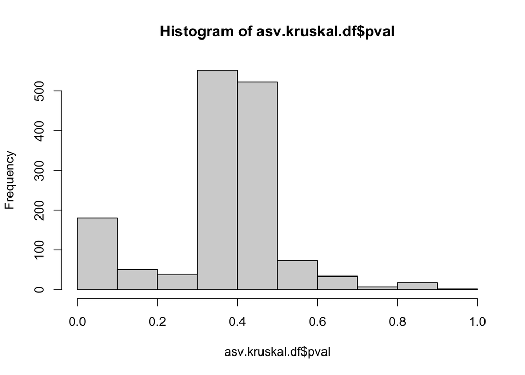

```r
#qvalue sometimes fails if it can't play nice with the distribution

hist(asv.kruskal.df$pval) #yah this is probably the problem
```

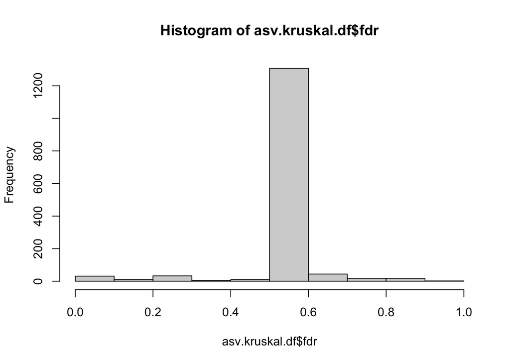

```r
#when this happens we can use fdr ( Benjamini & Hochberg )instead. Just be sure to use the same method of fdr throughout your project (i.e., don't use fdr and then qvalue)

asv.kruskal.df$fdr <- p.adjust(asv.kruskal.df$pval,method = "fdr")
rownames(asv.kruskal.df) <- asv.kruskal.df$asv
hist(asv.kruskal.df$fdr)
```

```r
sum(asv.kruskal.df$fdr < 0.1)
```

```
## [1] 31
```

Now lets look at some of these hits to make sure they look resonable

```r
sig_asv.df <- asv.kruskal.df[asv.kruskal.df$fdr < 0.1,]
head(sig_asv.df)
```

|  | asv | statistic | pval | fdr |
| --- | --- | --- | --- | --- |
| asv7 | asv7 | 20.15443 | 1.169017e-03 | 0.0762456810 |
| asv11 | asv11 | 20.06211 | 1.216629e-03 | 0.0762456810 |
| asv12 | asv12 | 35.38816 | 1.258744e-06 | 0.0009308415 |
| asv13 | asv13 | 36.44201 | 7.747815e-07 | 0.0009308415 |
| asv16 | asv16 | 18.84884 | 2.050798e-03 | 0.0986687722 |
| asv20 | asv20 | 32.19258 | 5.441692e-06 | 0.0026827542 |

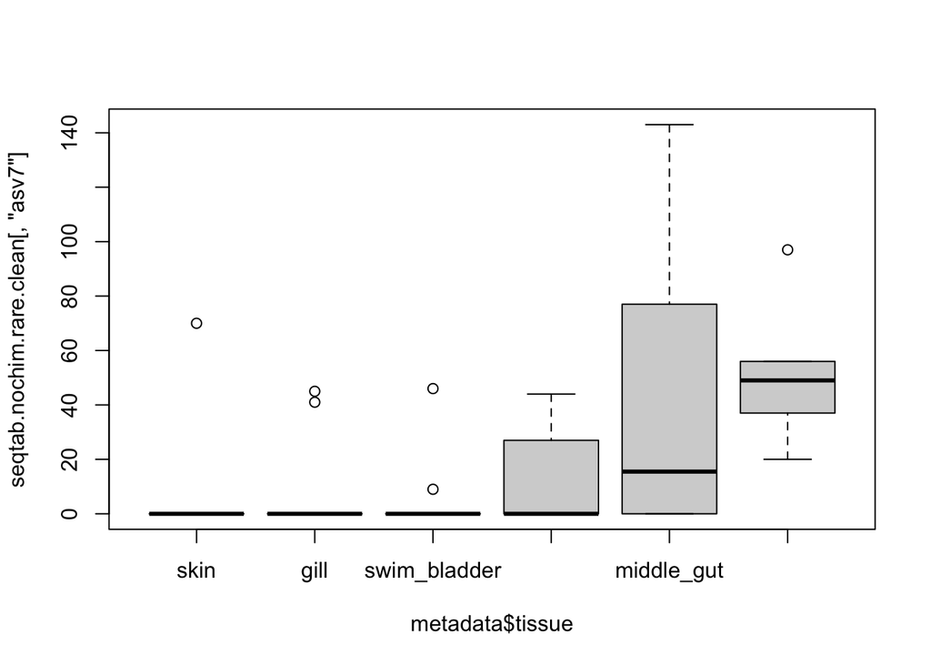

```r
boxplot(seqtab.nochim.rare.clean[,"asv7"] ~ metadata$tissue)
```

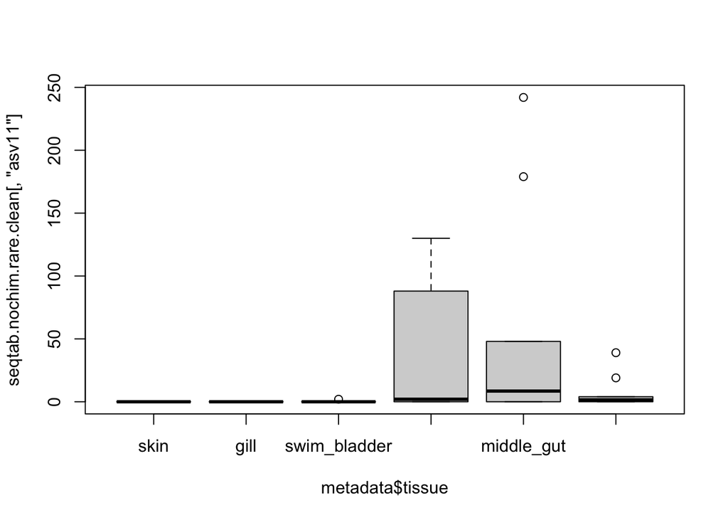

```r
boxplot(seqtab.nochim.rare.clean[,"asv11"] ~ metadata$tissue)
```

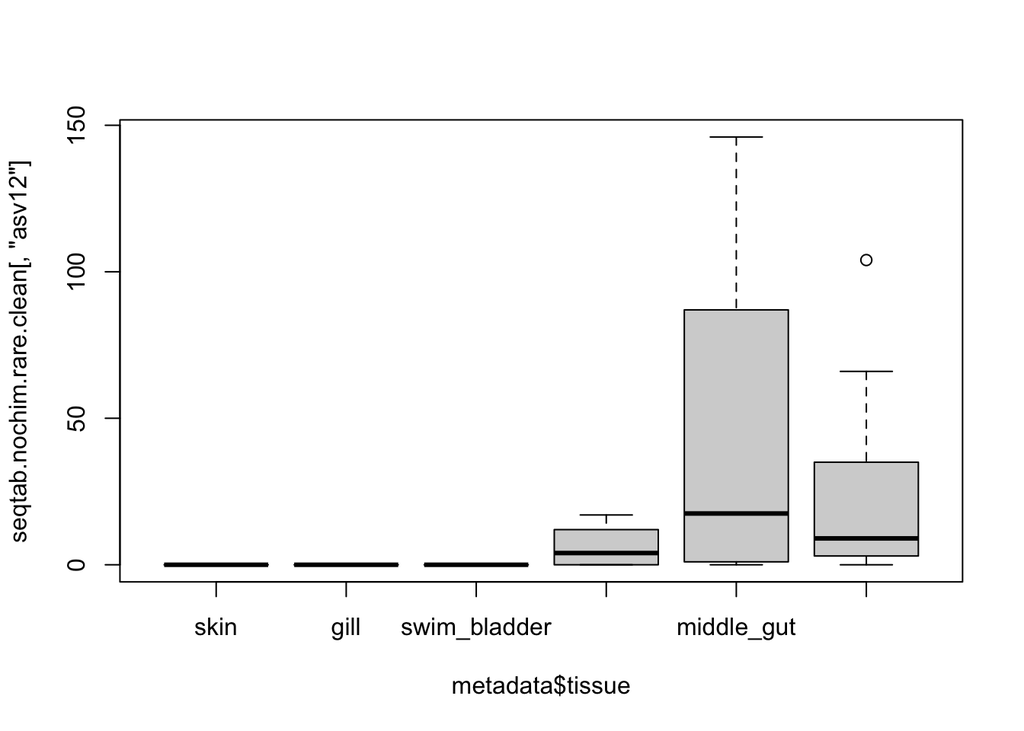

```r
boxplot(seqtab.nochim.rare.clean[,"asv12"] ~ metadata$tissue)
```

```r
#what taxa do we think these are
taxa["asv7","Genus"]
```

```
## [1] "Aeromonas"
```

```r
taxa["asv11","Genus"]
```

```
## [1] "Gemmata"
```

```r
taxa["asv12","Family"]
```

```
## [1] "Planococcaceae"
```

Note that the same approach can be implemented for more complex tests, you just have to be clear on what you are testing. It is also important to understand that non-parametric tests tend to have less statistical power.